# Simulation Results

Ning Leng

2019-12-17

# 1 Simulation structure

```r
for(i in 1:4){
  cat(paste0("## Heatmap: Simu ", i, ":", section.names[i],"\n\n\n"))
  simutmp <- get(paste0("simu.",i))
  heat.fun(simutmp[[1]])
  #print(summary.cor(simutmp[[1]]))
}
```

## 1.1 Heatmap: Simu 1:No shift, same cor, same coef

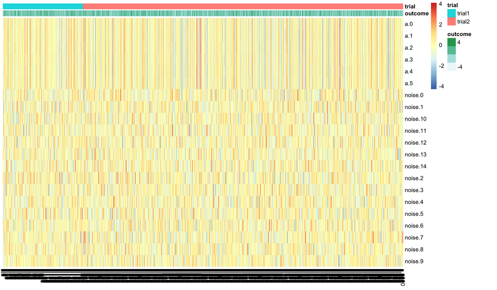

## Heatmap: Simu 2:No shift, different cor, same coef

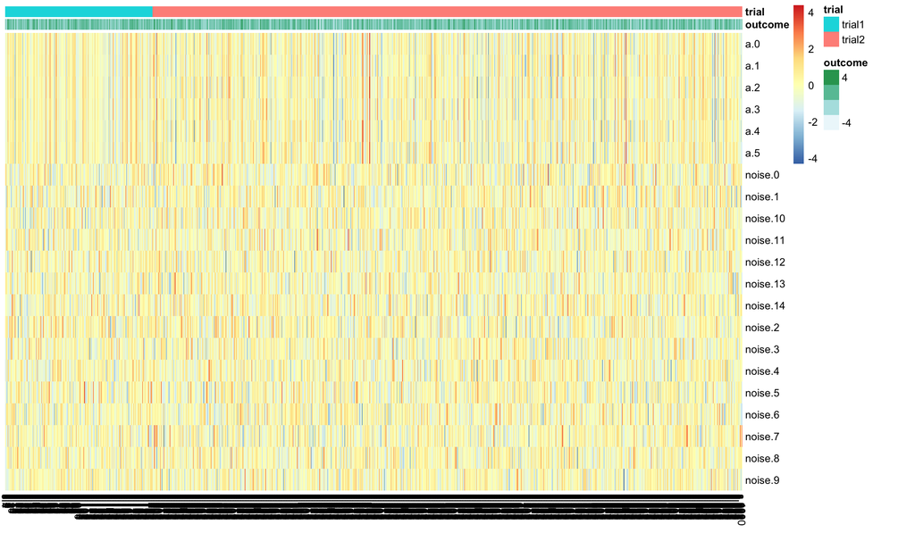

## Heatmap: Simu 3:No shift, same cor, diff coef

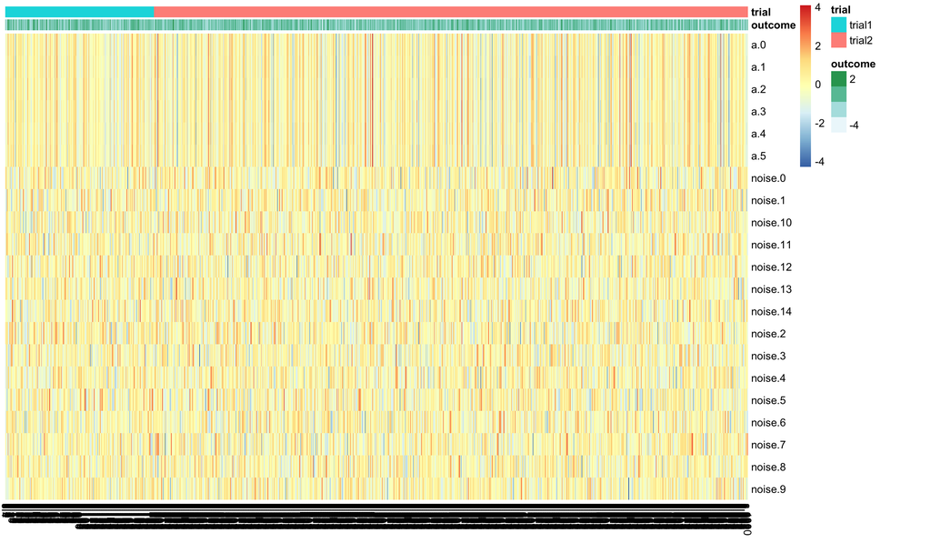

## Heatmap: Simu 4:With shift, same cor, same coef

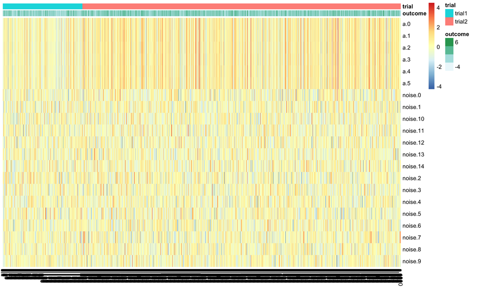

```r
for(i in 1:4){
  cat(paste0("## Statistics: Simu ", i, ":", section.names[i],"\n\n\n"))
  simutmp <- get(paste0("simu.",i))
  print(summary.cor(simutmp[[1]]))
}
```

```
## ## Statistics: Simu 1:No shift, same cor, same coef
```

```
## $xcor.trial1
##               a.0       a.1       a.2       a.3       a.4       a.5
## a.0     1.0000000 0.9878385 0.9878277 0.9883204 0.9886919 0.9897569
## a.1     0.9878385 1.0000000 0.9757201 0.9739602 0.9771635 0.9795348
## a.2     0.9878277 0.9757201 1.0000000 0.9748647 0.9778706 0.9778550
## a.3     0.9883204 0.9739602 0.9748647 1.0000000 0.9770505 0.9786742
## a.4     0.9886919 0.9771635 0.9778706 0.9770505 1.0000000 0.9780276
## a.5     0.9897569 0.9795348 0.9778550 0.9786742 0.9780276 1.0000000
## outcome 0.6459056 0.6297758 0.6419291 0.6203705 0.6238518 0.6308721
##           outcome
## a.0     0.6459056
## a.1     0.6297758
## a.2     0.6419291
## a.3     0.6203705
## a.4     0.6238518
## a.5     0.6308721
## outcome 1.0000000
##
## $xcor.trial2
##               a.0       a.1       a.2       a.3       a.4       a.5
## a.0     1.0000000 0.9912845 0.9906350 0.9916388 0.9912101 0.9905070
## a.1     0.9912845 1.0000000 0.9813514 0.9820572 0.9822238 0.9813188
## a.2     0.9906350 0.9813514 1.0000000 0.9823396 0.9816193 0.9820691
## a.3     0.9916388 0.9820572 0.9823396 1.0000000 0.9825705 0.9826096
## a.4     0.9912101 0.9822238 0.9816193 0.9825705 1.0000000 0.9808648
## a.5     0.9905070 0.9813188 0.9820691 0.9826096 0.9808648 1.0000000
## outcome 0.7522162 0.7504118 0.7416974 0.7424183 0.7442047 0.7418168
##           outcome
## a.0     0.7522162
## a.1     0.7504118
## a.2     0.7416974
## a.3     0.7424183
## a.4     0.7442047
## a.5     0.7418168
## outcome 1.0000000
##
## $x.shift
## # A tibble: 2 x 2
##   trial  a0_mean
##   <chr>    <dbl>
```

[output cut: 165 more lines]

```
## # A tibble: 2 x 2
##   trial  a0_mean
##   <chr>    <dbl>
## 1 trial1  0.0355
## 2 trial2  0.479
##
## $model.trial1
##               Estimate Std. Error   t value     Pr(>|t|)
## (Intercept) -0.1425619 0.06805335 -2.094854 3.745585e-02
## a.0          1.0645231 0.07337662 14.507660 5.751605e-33
##
## $model.trial2
##                Estimate Std. Error   t value      Pr(>|t|)
## (Intercept) -0.01743882 0.03776394 -0.461785  6.443613e-01
## a.0          1.00852177 0.03235154 31.173837 3.606931e-140
```

# 2 Analysis, all x observed

```r
for(i in 1:4){
  cat(paste0("## Simu ", i, ":", section.names[i],"\n\n\n"))
  for(obs.subset in c(TRUE)){
    suffix <- ifelse(obs.subset,"","noa0")
    simuname.out <- paste0("simu.",i, suffix)
    cat(paste0("Causal feacture observed? ", obs.subset, '\n\n\n'))

    cat("### Top selected features \n\n\n")
    res.v <- readRDS(paste0(simuname.out, ".res.v.rds"))
    lasso.top <- sapply(res.v, function(i)i$lasso.top.names[1])
    print(table(lasso.top))
    cat("\n\n\n")

    uni.top <- sapply(res.v, function(i)i$uni.top.names[1])
    print(table(uni.top))
    cat("\n\n\n")
    cat("### MSE \n\n\n")
    mse.plot.df <- readRDS(paste0(simuname.out,".mse.plot.df.rds"))
    mse.tab <- mse.plot.df %>% group_by(model, method) %>% summarise(mean=mean(mse), median=median(mse))
    print(kable(mse.tab))
    cat("\n\n\n")

  }
}
```

## 2.1 Simu 1:No shift, same cor, same coef

Causal feacture observed? TRUE

### 2.1.1 Top selected features

lasso.top a.0 a.1 a.3 a.4 a.5 5 1 1 1 2

uni.top a.0 a.1 a.3 a.4 a.5 5 1 1 1 2

### 2.1.2 MSE

| model | method | mean | median |
| --- | --- | --- | --- |
| lasso | lasso.trial1 | 1.027093 | 1.018952 |
| lasso | lasso.trial2 | 1.064863 | 1.061842 |
| lasso | lasso.trial1.bootcorrection | 1.097025 | 1.081421 |
| unitop | unitop.trial1 | 1.061699 | 1.070525 |
| unitop | unitop.trial2 | 1.039388 | 1.051438 |
| unitop | unitop.trial1.bootcorrection | 1.084622 | 1.091396 |

## 2.2 Simu 2:No shift, different cor, same coef

Causal feacture observed? TRUE

### 2.2.1 Top selected features

lasso.top a.0 a.1 a.3 a.4 a.5 5 1 1 1 2

uni.top a.0 a.1 a.3 a.4 a.5 5 1 1 1 2

### 2.2.2 MSE

| model | method | mean | median |
| --- | --- | --- | --- |
| lasso | lasso.trial1 | 1.027093 | 1.018952 |
| lasso | lasso.trial2 | 1.116761 | 1.112333 |
| lasso | lasso.trial1.bootcorrection | 1.096731 | 1.080053 |
| unitop | unitop.trial1 | 1.061699 | 1.070525 |
| unitop | unitop.trial2 | 1.134885 | 1.144929 |
| unitop | unitop.trial1.bootcorrection | 1.078937 | 1.083370 |

## 2.3 Simu 3:No shift, same cor, diff coef

Causal feacture observed? TRUE

### 2.3.1 Top selected features

lasso.top a.0 a.1 a.3 a.4 a.5 5 1 1 1 2

uni.top a.0 a.1 a.3 a.4 a.5 5 1 1 1 2

### 2.3.2 MSE

| model | method | mean | median |
| --- | --- | --- | --- |
| lasso | lasso.trial1 | 1.027093 | 1.018952 |
| lasso | lasso.trial2 | 1.129390 | 1.096343 |
| lasso | lasso.trial1.bootcorrection | 1.096205 | 1.090030 |
| unitop | unitop.trial1 | 1.061699 | 1.070525 |
| unitop | unitop.trial2 | 1.177454 | 1.151859 |
| unitop | unitop.trial1.bootcorrection | 1.087318 | 1.089528 |

## 2.4 Simu 4:With shift, same cor, same coef

Causal feacture observed? TRUE

### 2.4.1 Top selected features

lasso.top a.0 a.1 a.2 a.3 a.4 a.5 1 2 1 1 3 2

uni.top a.0 a.1 a.2 a.3 a.4 a.5 1 2 1 1 3 2

### 2.4.2 MSE

| model | method | mean | median |
| --- | --- | --- | --- |
| lasso | lasso.trial1 | 1.042502 | 1.033814 |
| lasso | lasso.trial2 | 1.050875 | 1.047895 |
| lasso | lasso.trial1.bootcorrection | 1.099552 | 1.102549 |
| unitop | unitop.trial1 | 1.051879 | 1.054026 |
| unitop | unitop.trial2 | 1.040837 | 1.041335 |
| unitop | unitop.trial1.bootcorrection | 1.066073 | 1.076377 |

# 3 Analysis, a.0 (causal) not observed

```r
for(i in 1:4){
  cat(paste0("## Simu ", i, ":", section.names[i],"\n\n\n"))
  for(obs.subset in c(FALSE)){
    suffix <- ifelse(obs.subset,"","noa0")
    simuname.out <- paste0("simu.",i, suffix)
    cat(paste0("Causal feacture observed? ", obs.subset, '\n\n\n'))

    cat("### Top selected features \n\n\n")
    res.v <- readRDS(paste0(simuname.out, ".res.v.rds"))
    lasso.top <- sapply(res.v, function(i)i$lasso.top.names[1])
    print(table(lasso.top))
    cat("\n\n\n")
    uni.top <- sapply(res.v, function(i)i$uni.top.names[1])
    print(table(uni.top))
    cat("\n\n\n")
    cat("### MSE \n\n\n")
    mse.plot.df <- readRDS(paste0(simuname.out,".mse.plot.df.rds"))
    mse.tab <- mse.plot.df %>% group_by(model, method) %>% summarise(mean=mean(mse), median=median(mse))
    print(kable(mse.tab))
        cat("\n\n\n")

  }
}
```

## 3.1 Simu 1:No shift, same cor, same coef

Causal feacture observed? FALSE

### 3.1.1 Top selected features

lasso.top a.1 a.2 a.3 a.4 a.5 2 2 1 1 4

uni.top a.1 a.2 a.3 a.4 a.5 2 2 1 1 4

### 3.1.2 MSE

| model | method | mean | median |
| --- | --- | --- | --- |
| lasso | lasso.trial1 | 1.027774 | 1.018230 |
| lasso | lasso.trial2 | 1.067958 | 1.064114 |
| lasso | lasso.trial1.bootcorrection | 1.095029 | 1.081229 |
| unitop | unitop.trial1 | 1.064649 | 1.072381 |
| unitop | unitop.trial2 | 1.050521 | 1.065406 |
| unitop | unitop.trial1.bootcorrection | 1.098944 | 1.100738 |

## 3.2 Simu 2:No shift, different cor, same coef

Causal feacture observed? FALSE

### 3.2.1 Top selected features

lasso.top a.1 a.2 a.3 a.4 a.5 2 2 1 1 4

uni.top a.1 a.2 a.3 a.4 a.5 2 2 1 1 4

### 3.2.2 MSE

| model | method | mean | median |
| --- | --- | --- | --- |
| lasso | lasso.trial1 | 1.027774 | 1.018230 |
| lasso | lasso.trial2 | 1.159604 | 1.151612 |
| lasso | lasso.trial1.bootcorrection | 1.101723 | 1.081434 |
| unitop | unitop.trial1 | 1.064649 | 1.072381 |
| unitop | unitop.trial2 | 1.239801 | 1.240197 |
| unitop | unitop.trial1.bootcorrection | 1.130093 | 1.123801 |

## 3.3 Simu 3:No shift, same cor, diff coef

Causal feacture observed? FALSE

### 3.3.1 Top selected features

lasso.top a.1 a.2 a.3 a.4 a.5 2 2 1 1 4

uni.top a.1 a.2 a.3 a.4 a.5 2 2 1 1 4

### 3.3.2 MSE

| model | method | mean | median |
| --- | --- | --- | --- |
| lasso | lasso.trial1 | 1.027774 | 1.018230 |
| lasso | lasso.trial2 | 1.131209 | 1.100307 |
| lasso | lasso.trial1.bootcorrection | 1.094649 | 1.089562 |
| unitop | unitop.trial1 | 1.064649 | 1.072381 |
| unitop | unitop.trial2 | 1.182371 | 1.155403 |
| unitop | unitop.trial1.bootcorrection | 1.093411 | 1.093959 |

## 3.4 Simu 4:With shift, same cor, same coef

Causal feacture observed? FALSE

### 3.4.1 Top selected features

lasso.top a.1 a.2 a.3 a.4 a.5 2 1 1 3 3

uni.top a.1 a.2 a.3 a.4 a.5 2 1 1 3 3

### 3.4.2 MSE

| model | method | mean | median |
| --- | --- | --- | --- |
| lasso | lasso.trial1 | 1.043244 | 1.033863 |
| lasso | lasso.trial2 | 1.053336 | 1.048734 |
| lasso | lasso.trial1.bootcorrection | 1.100307 | 1.110431 |
| unitop | unitop.trial1 | 1.053446 | 1.054026 |
| unitop | unitop.trial2 | 1.042613 | 1.050217 |
| unitop | unitop.trial1.bootcorrection | 1.076337 | 1.080347 |